# KushagraBifurcations

# Task-2

Write a function that will take values for $x$, $\alpha$ and the number of steps and plot the Phase Plot for these steps.

```
(0.5580140850384046, 0.764566534405186, 0.5580141015057717)
```

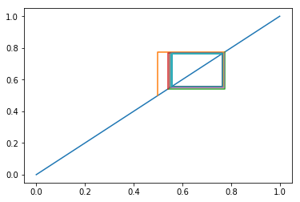

```python
def Task0(a,x):
    return a*x*(1-x)

def Task2(a,xx,n):
    x=xx
    plt.plot([0,1],[0,1])
    for i in range(n):
        y=Task0(a,x)
        plt.plot([x,x,y],[x,y,y])
        x=y
    return y,Task0(a,y),Task0(a,Task0(a,y))

Task2(3.1,0.5,50)
#the value of x starts at 0.5 and continues to converge to either of the steady states which are 0.558.. and 0.7645.. and once it reaches that value it continues to recurse in a rectangle
#this graph shows that for a=3.1 xn=xn+2 and once it converges to a steady state it continues to alternate between them
```

```
(0.5580141252026958, 0.7645665199585945, 0.5580141252026958)
```

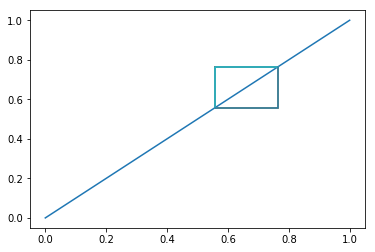

```python
Task2(3.1,0.5580141252026958,1000)

#here i started off with the value i got as a steady state from previous run
#now because we started off with a steady state value the phase plot contains only four values
#the four values are
#(0.558...,0.558...),(0.558...,0.764...),(0.764...,0.764...),(0.764...,0.558...)
```

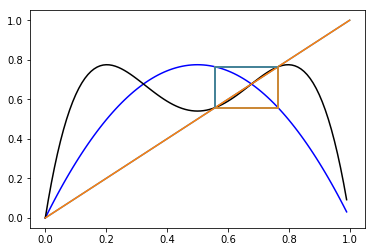

```python
def Task2c(a,xx,n):
    plt.plot([0,1],[0,1])
    cc=np.arange(0,1,0.01)
    yy=np.array(Task0(a,cc))
    zz=np.array(Task0(a,yy))
    plt.plot(cc,yy,c="blue")
    plt.plot(cc,zz,c="black")
    Task2(3.1,0.5580141252026958,1000)
Task2c(3.1,0.5,1000)
#we can see from the graph that y=x and y=f(x) cut at two points
#y=x and y=f(f(x)) cuts at four points out of which two are same as y=f(x)
#the other two are placed such that the non zero root bisects them
```

# Task-3

Write a function, for a particular value of $\alpha$, to determine steady states and cycles (lets denote these values as $x^*(\alpha)$.  
HINT-1: consider $f(x)$, $f(f(x))=f^2(x)$, $f^3(x)$,...,$f^n(x)$  
HINT-2: You might want to use the function *isclose* defined below:

```
def isclose(a,b,delta):
''' if the difference between a and b
    is less than delta, then returns True.
    Else returns False'''
    return fabs(a-b) < delta
```

```python
import numpy as np
import matplotlib.pyplot as plt
def Task4a(a,x):
    return a*x*(1-x)

def Task4b(a,xx):
    b=[0]*10000
    b[0]=xx
    #i will be storing the values of f(f(...(x))) in b
    for i in range(1,10000):
        b[i]=Task4a(a,b[i-1])
    val=b[9000]
    #i chose to take the ending 1000 values so that i can get past the initial fluctuations
    pos=9000
    for i in range(9001,10000):
        if(abs(b[i]-val)<0.000001):
        #i implemented the isclose function using the above if statement
            pos=i
            break
    #as soon as i get a value in b[>9000] which is equal to b[9000]
    #i can be sure that a complete cycle has occured and so i get the number of cycles
    print("The number of cycles is : ",pos-9000)
    print("The steady states are as follows : ")
    for i in range(9000,pos):
        print(b[i])
    #the values in b form 9000 to pos-1 are basically the steady states for that cycle
```

```python
Task4b(2,0.5)
```

```
The number of cycles is :  1
The steady states are as follows :
0.5
```

```python
Task4b(1,0.5)
```

```
The number of cycles is :  1
The steady states are as follows :
0.00011097702465432266
```

```python
Task4b(3,0.5)
```

```
The number of cycles is :  2
The steady states are as follows :
0.6641749563334927
0.6691397511386873
```

```python
Task4b(3.25,0.5)
```

```
The number of cycles is :  2
The steady states are as follows :
0.4952651682454746
0.8124271394468331
```

```python
Task4b(3.5697456,0.5)
```

```
The number of cycles is :  64
The steady states are as follows :
0.47581665318648764
0.8903486904625603
0.3485067659416437
0.8105100246541793
0.5482541111350061
0.8841243928681276
0.3657149064832973
0.8280650112279063
0.5082366340368453
0.8921942208183232
0.34335131543790964
0.8048390896344906
0.5607111126638824
0.8792788917303276
0.37891965063782757
0.8401023195427881
0.4795253980456921
0.8909399293559334
0.3468577997144009
0.8087168216998416
0.5522179545441217
0.8827027219231632
0.3696065568517738
0.8317419788659867
0.4995761136825368
0.8924357585895024
0.3426747851893892
0.8040808298329046
0.5623593338078643
0.8785547784305793
0.38087857509316625
0.84178201739164
0.475436755460713
0.890282583346199
0.3486909836716167
0.8107091505725678
0.547812530610028
0.8842758256105829
```

[output cut: 11 more lines]

```
0.8910786644915343
0.34647050567843024
0.8082928354530575
0.5531518128754574
0.8823514574026569
0.37056587739561664
0.8326317662351802
0.4974658536919156
0.8924134754596171
0.3427372161040127
0.8041509396953497
0.5622071089831192
0.8786224683211948
0.38069561404730884
0.8416262956797388
```

```python
Task4b(3.46,0.5)
```

```
The number of cycles is :  4
The steady states are as follows :
0.4674861779469948
0.8613422657592492
0.41323391373686347
0.8389518961100396
```

```python
Task4b(3.56945,0.5)
```

```
The number of cycles is :  32
The steady states are as follows :
0.47608818639022304
0.8903215783326683
0.34855345680576555
0.8104933968901202
0.5482455696230861
0.8840541232911694
0.3658773001307823
0.8281520258200977
0.5079907312457197
0.8921345842430286
0.3434898434334408
0.8049272905687043
0.560472709814045
0.879309204704602
0.3788061937081389
0.8399346372661483
0.47989271487732127
0.8909193609600363
0.346886479889676
0.8086812064176709
0.5522507149601339
0.8826174117220403
0.3698089988483063
0.8318614048254866
0.49925186111010544
0.8923605021367206
0.34285722453598344
0.8042190304050267
0.562012692165902
0.8786359159225977
0.3806277409654908
0.8414987790245277
```

# Task-4

Plot $\alpha$ vs $x^*(\alpha)$. Comment.

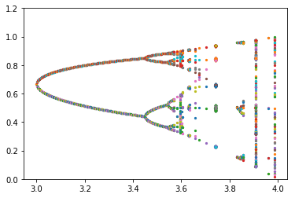

```python
import numpy as np
import matplotlib.pyplot as plt
def Task5a(a,x):
    return a*x*(1-x)

def Task5b(xx):
    b=[0]*10000
    b[0]=xx
    plt.ylim(top=1.2)
    #because the upper limit of y is 1 so a top of 1.2 scales the graph nicely
    xv=np.arange(3,4,0.001)
    #for numbers in the range 3-4 i chose the least count to be 0.0001 for a
    for j in xv:
        for i in range(1,10000):
            b[i]=Task5a(j,b[i-1])
        val=b[9000]
        pos=9000
        for i in range(9001,10000):
            if(abs(b[i]-val)<0.000001):
                pos=i
                break
        #storing all the steady states in a new array
        c=[0]*(pos-9000)
        d=pos-9000
        for i in range(d):
            c[i]=b[i+9000]
            #using scatter plot
            plt.scatter(j,c[i],s=5)
def Task5c(xx):
    b=[0]*10000
    b[0]=xx
    plt.ylim(top=1.2)
    xv=np.arange(0,3,0.01)
    #for a in 0-3 i chose least count to be 0.01 so that i can reduce time complexity
    #in this process i am not losing out on any bifurcations as i know that for these a's there is only one steady state
    for j in xv:
        for i in range(1,10000):
            b[i]=Task5a(j,b[i-1])
        val=b[9000]
        pos=9000
        for i in range(9001,10000):
            if(abs(b[i]-val)<0.00001):
                pos=i
                break
        c=[0]*(pos-9000)
        d=pos-9000
        for i in range(d):
            c[i]=b[i+9000]
            plt.scatter(j,c[i],s=6)
Task5b(0.5)
#this graph shows in more clarity what happens in ranges 3-4
```

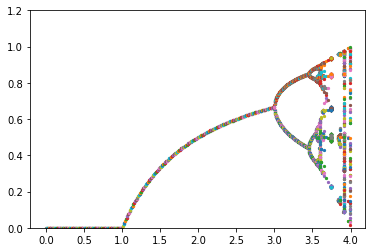

```python
Task5b(0.5)
Task5c(0.5)
#plots the complete bifurcation diagram
```

# Task-5

Find the ratio between two consequtive bifurcations.

```python
import numpy as np
import matplotlib.pyplot as plt


def Task6a(a,x):
    return a*x*(1-x)

def Task6b(xx):
    answer=[0]*100
    #array to store number of bifurcations
    beta=[0]*100
    #array to store value of alpha
    beta[0]=3
    answer[0]=2
    count=0
    b=[0]*10000
    b[0]=xx
    xv=np.arange(3,3.57,0.0001)
    #i started the calculation for alpha from 3 and not 0
    #because as the number of bifurcations increase the ratio is more accurate
    for j in xv:
        for i in range(1,10000):
            b[i]=Task6a(j,b[i-1])
        val=b[9000]
        pos=9000
        for i in range(9001,10000):
            if(abs(b[i]-val)<0.000001):
                pos=i
                break
        d=pos-9000
        if(d>answer[count]):
        #if number of bifurcations increased(practically doubled) then alpha is stored
            count+=1
            answer[count]=d
            beta[count]=j
    print("Value of alpha and number of bifurcations for that alpha:")
    print("")
    for i in range(count+1):
        print(beta[i],answer[i])
    g=0
    print("")
    print("The ratio calculated for these bifurcations")
    print("")
    for i in range(1,count):
        r=beta[i+1]-beta[i]
        s=beta[i]-beta[i-1]
        g+=s/r
        print(s/r)
    print("")
    print("Mean Value for the Ratio : ",g/(count-1))
    #the mean value should be close to the feigenbaums constant 4.669..
```

```python
Task6b(0.5)
#indeed the value of ratio 4.6819.. is close to the feigenbaums constant 4.669..
#as we increase the number of cycles we can compute the ratio tends closer to the constant
```

```
Value of alpha and number of bifurcations for that alpha:

3 2
3.4491000000009477 4
3.544000000001148 8
3.564400000001191 16
3.5688000000012003 32
3.5697000000012022 64
3.5699000000012027 128

The ratio calculated for these bifurcations

4.732349841938883
4.651960784313726
4.636363636363637
4.888888888888889
4.5

Mean Value for the Ratio :  4.681912630301027
```